# 데이터 공학 R마크다운 과제 보고서

2013122053 박상우

12/13/2019

**데이터 불러오기**

```r
category<- tbl(con, "category") %>% collect()
inventory<- tbl(con, "inventory") %>% collect()
customer<- tbl(con, "customer") %>% collect()
film_category<- tbl(con, "film_category") %>% collect()
rental<- tbl(con, "rental") %>% collect()
film<- tbl(con, "film") %>% collect()
payment<- tbl(con, "payment") %>% collect()
address<- tbl(con, "address") %>% collect()
city<- tbl(con, "city") %>% collect()
staff<- tbl(con, "staff") %>% collect()
country<- tbl(con, "country") %>% collect()
film_actor<- tbl(con, "film_actor") %>% collect()
actor<- tbl(con, "actor") %>% collect()
store<- tbl(con, "store") %>% collect()
```

# 1 What are the top and least rented (in-demand) genres and what are their total sales?

```r
model_1<-dm_from_data_frames(category, inventory, film_category, rental, film, customer, payment)

model_1<-dm_add_references(model_1,
  category$category_id == film_category$category_id,
  inventory$inventory_id == rental$inventory_id,
  film_category$film_id == film$film_id,
  film$film_id == inventory$film_id,
  rental$customer_id == customer$customer_id,
  rental$rental_id == payment$rental_id
)

model_1_graph <- dm_create_graph(model_1, rankdir="LR",col_attr=c("column", "type"))
dm_render_graph(model_1_graph)
```

[interactive chart not shown]

```r
qry1 <- "WITH A1 AS (SELECT c.name AS Genre,
                      COUNT(cu.customer_id) AS Total_rent_demand
                      FROM category as c
                      INNER JOIN film_category as fc
                      USING(category_id)
                      INNER JOIN film as f
                      USING(film_id)
                      INNER JOIN inventory as i
                      USING(film_id)
                      INNER JOIN rental as r
                      USING(inventory_id)
                      INNER JOIN customer as cu
                      USING(customer_id)
                      GROUP BY c.name
                      ORDER BY 2 DESC),
              A2 AS (SELECT c.name AS Genre,
                      SUM(p.amount) AS Total_sales
                      FROM category as c
                      INNER JOIN film_category as fc
                      USING(category_id)
                      INNER JOIN film as f
                      USING(film_id)
                      INNER JOIN inventory as i
                      USING(film_id)
                      INNER JOIN rental as r
                      USING(inventory_id)
                      INNER JOIN payment as p
                      USING(rental_id)
                      GROUP BY c.name
                      ORDER BY 2 DESC)
          SELECT A1.genre, A1.total_rent_demand, A2.total_sales
          FROM A1
          JOIN A2
          ON A1.genre = A2.genre;"

answer1 <- dbGetQuery(con, qry1)
DT::datatable(answer1)
```

|  | genre | total_rent_demand | total_sales |
| --- | --- | --- | --- |
| 1 | Sports | 1179 | 4892.19 |
| 2 | Animation | 1166 | 4245.31 |
| 3 | Action | 1112 | 3951.84 |
| 4 | Sci-Fi | 1101 | 4336.01 |
| 5 | Family | 1096 | 3830.15 |
| 6 | Drama | 1060 | 4118.46 |
| 7 | Documentary | 1050 | 3749.65 |
| 8 | Foreign | 1033 | 3934.47 |
| 9 | Games | 969 | 3922.18 |
| 10 | Children | 945 | 3309.39 |

[output cut: 6 more lines]

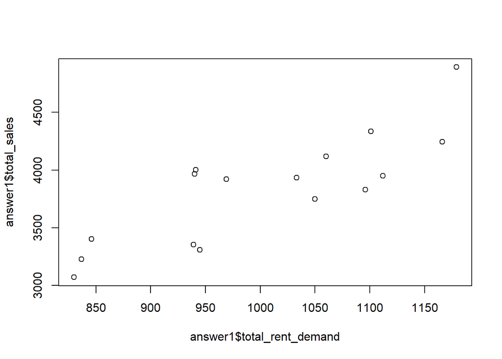

```r
plot(answer1$total_rent_demand,answer1$total_sales)
```

```r
reg<-lm(total_sales~total_rent_demand,data=answer1)
summary(reg)
```

```
##
## Call:
## lm(formula = total_sales ~ total_rent_demand, data = answer1)
##
## Residuals:
##     Min      1Q  Median      3Q     Max
## -326.33 -249.27  -15.34  173.50  446.90
##
## Coefficients:
##                   Estimate Std. Error t value Pr(>|t|)
## (Intercept)       342.7816   619.6519   0.553    0.589
## total_rent_demand   3.4797     0.6143   5.665 5.84e-05 ***
## ---
## Signif. codes:  0 '***' 0.001 '**' 0.01 '*' 0.05 '.' 0.1 ' ' 1
##
## Residual standard error: 269.6 on 14 degrees of freedom
## Multiple R-squared:  0.6962, Adjusted R-squared:  0.6745
## F-statistic: 32.09 on 1 and 14 DF,  p-value: 5.84e-05
```

**가장 높은 rent 수요를 보인 장르는 Sport이고 이때의 총 판매액은 4892.19이다.**

**반면 가장 낮은 rent 수요를 보인 장르는 Music 이고 이때의 총 판매액은 3071.52이다.**

**추가적으로, 경제학적으로 보았을 때,rent 수요와 총 판매액 간의 관계를 살펴보기 위해 plot을 그려보았다.**

**그 결과, 두 변수 간의 양의 상관관계가 존재한다는 생각이 들었고 이에 추가적으로, 회귀분석을 진행한 결과, demand가 한단위 증가할 수록 sales는 3.48가량 늘어났다.**

**다만, 이 회귀모델의 R스퀘어는 0.69로 높지는 않았다.**

# 2 Can we know how many distinct users have rented each genre?

```r
model_2 <- dm_from_data_frames(category, film_category, film,
                                inventory, rental, customer)

model_2 <- dm_add_references(model_2,
  category$category_id == film_category$category_id,
  film_category$film_id == film$film_id,
  film$film_id == inventory$film_id,
  inventory$inventory_id == rental$inventory_id,
  rental$customer_id == customer$customer_id
)

model_2_graph <- dm_create_graph(model_2, rankdir="LR", col_attr=c("column", "type"))
dm_render_graph(model_2_graph)
```

[interactive chart not shown]

```r
qry2 <- "SELECT c.name AS Genre,
          COUNT(DISTINCT cu.customer_id) AS Total_rent_demand_distinct
          FROM category as c
          INNER JOIN film_category as fc
          USING(category_id)
          JOIN film as f
          USING(film_id)
          JOIN inventory as i
          USING(film_id)
          JOIN rental as r
          USING(inventory_id)
          JOIN customer as cu
          USING(customer_id)
          GROUP BY c.name
          ORDER BY 2 DESC;"
answer2 <- dbGetQuery(con, qry2)
DT::datatable(answer2)
```

|  | genre | total_rent_demand_distinct |
| --- | --- | --- |
| 1 | Sports | 519 |
| 2 | Action | 510 |
| 3 | Sci-Fi | 507 |
| 4 | Family | 501 |
| 5 | Drama | 501 |
| 6 | Animation | 500 |
| 7 | Comedy | 495 |
| 8 | Foreign | 493 |
| 9 | Documentary | 483 |
| 10 | Children | 482 |

[output cut: 6 more lines]

**분석 결과, 장르별 고유한 사용자수를 파악할 수 있었고, 스포츠 장르가 519로 가장 높았고 여행 분야가 442로 가장 낮음을 확인할 수 있었다.**

# 3 What is the average rental rate for each genre? (from the highest to the lowest)

```r
model_3 <- dm_from_data_frames(category, film_category, film)

model_3 <- dm_add_references(model_3,
  category$category_id == film_category$category_id,
  film_category$film_id == film$film_id
)

model_3_graph <- dm_create_graph(model_3, rankdir="LR", col_attr=c("column", "type"))
dm_render_graph(model_3_graph)
```

[interactive chart not shown]

```r
qry3 <- "SELECT c.name AS Genre,
          ROUND(AVG(f.rental_rate),2) AS average_rental_rate
          FROM category as c
          INNER JOIN film_category as fc
          USING(category_id)
          INNER JOIN film as f
          USING(film_id)
          GROUP BY c.name
          ORDER BY 2 DESC;"

answer3 <- dbGetQuery(con, qry3)
DT::datatable(answer3)
```

|  | genre | average_rental_rate |
| --- | --- | --- |
| 1 | Games | 3.25 |
| 2 | Travel | 3.24 |
| 3 | Sci-Fi | 3.22 |
| 4 | Comedy | 3.16 |
| 5 | Sports | 3.13 |
| 6 | New | 3.12 |
| 7 | Foreign | 3.1 |
| 8 | Horror | 3.03 |
| 9 | Drama | 3.02 |
| 10 | Music | 2.95 |

[output cut: 6 more lines]

**평균 대여 비율의 경우, 게임이 3.25로 가장 높았고 액션 장르가 2.65로 가장 낮음을 확인할 수 있었다.**

# 4 How many rented films were returned late, early, and on time?

```r
model_4<- dm_from_data_frames(film, inventory, rental)

model_4 <- dm_add_references(model_4,
  film$film_id == inventory$film_id,
  inventory$inventory_id == rental$inventory_id
)

model_4_graph <- dm_create_graph(model_4, rankdir="LR", col_attr=c("column", "type"))
dm_render_graph(model_4_graph)
```

[interactive chart not shown]

```r
qry4 <- "WITH A1 AS (SELECT *, DATE_PART('day', return_date - rental_date) AS date_difference
                      FROM rental),
          A2 AS (SELECT rental_duration, date_difference,
                        CASE
                          WHEN rental_duration > date_difference THEN 'Returned early'
                          WHEN rental_duration = date_difference THEN 'Returned on Time'
                          ELSE 'Returned late'
                        END AS Return_status
                  FROM film f
                  INNER JOIN inventory i
                  USING(film_id)
                  INNER JOIN A1
                  USING(inventory_id))
          SELECT Return_status, COUNT(*) AS total_number_of_films
          FROM A2
          GROUP BY 1
          ORDER BY 2 DESC;"

answer4<- dbGetQuery(con, qry4)
DT::datatable(answer4)
```

|  | return_status | total_number_of_films |
| --- | --- | --- |
| 1 | Returned early | 7738 |
| 2 | Returned late | 6586 |
| 3 | Returned on Time | 1720 |

**이르게 반납된 영화의 갯수는 7738개, 제 기간에 반납된 영화는 1720개, 그리고 늦게 반납된 영화는 6586개 였다.**

# 5 In which countries does Rent A Film have a presence and what is the customer base in each country? What are the total sales in each country? (from most to least)

```r
model_5 <- dm_from_data_frames(country, city, address, customer, payment)

model_5 <- dm_add_references(model_5,
  country$country_id == city$country_id,
  city$city_id == address$city_id,
  address$address_id == customer$address_id,
  customer$customer_id == payment$customer_id
)

model_5_graph <- dm_create_graph(model_5, rankdir="LR", col_attr=c("column", "type"))
dm_render_graph(model_5_graph)
```

[interactive chart not shown]

```r
qry5 <- "SELECT country,
                COUNT(DISTINCT customer_id) AS customer_base,
                SUM(amount) AS total_sales
          FROM country
          INNER JOIN city as ct
          USING(country_id)
          INNER JOIN address as ad
          USING(city_id)
          INNER JOIN customer as cu
          USING(address_id)
          INNER JOIN payment as p
          USING(customer_id)
          GROUP BY country
          ORDER BY 2 DESC, 3 DESC;"

answer5 <- dbGetQuery(con, qry5)
DT::datatable(answer5)
```

|  | country | customer_base | total_sales |
| --- | --- | --- | --- |
| 1 | India | 60 | 6034.78 |
| 2 | China | 53 | 5251.03 |
| 3 | United States | 36 | 3685.31 |
| 4 | Japan | 31 | 3122.51 |
| 5 | Mexico | 30 | 2984.82 |
| 6 | Brazil | 28 | 2919.19 |
| 7 | Russian Federation | 28 | 2765.62 |
| 8 | Philippines | 20 | 2219.7 |
| 9 | Turkey | 15 | 1498.49 |
| 10 | Indonesia | 14 | 1352.69 |

[output cut: 98 more lines]

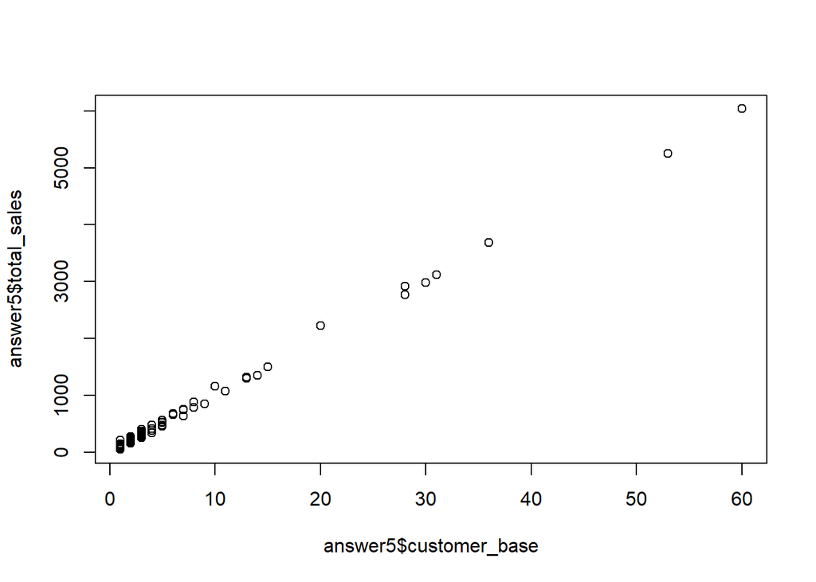

```r
plot(answer5$customer_base,answer5$total_sales)
```

```r
reg1<-lm(total_sales~customer_base,data=answer5)
summary(reg1)
```

```
##
## Call:
## lm(formula = total_sales ~ customer_base, data = answer5)
##
## Residuals:
##     Min      1Q  Median      3Q     Max
## -89.392 -28.667  -5.603  19.534 198.296
##
## Coefficients:
##               Estimate Std. Error t value Pr(>|t|)
## (Intercept)     9.8781     4.9852   1.981   0.0501 .
## customer_base 100.5763     0.4464 225.321   <2e-16 ***
## ---
## Signif. codes:  0 '***' 0.001 '**' 0.01 '*' 0.05 '.' 0.1 ' ' 1
##
## Residual standard error: 44.97 on 106 degrees of freedom
## Multiple R-squared:  0.9979, Adjusted R-squared:  0.9979
## F-statistic: 5.077e+04 on 1 and 106 DF,  p-value: < 2.2e-16
```

**인도가 60개의 가장 많은 customer base를 가지며 총 판매량 또한 6034.78로 가장 높았다.**

**반면 아메리카 사모아라는 나라가 가장 적은 customer base를 가지고 있었으며, customer base가 1개인 여러 나라들 중에서도 가장 작고 전체 국가에서도 가장 작은 47.85의 판매량을 보였다.**

**추가적으로, customer_base와 total_sales이 관계를 plot으로 그려본 결과, 양의 선형관계를 파악할 수 있었고 회귀분석 결과, customer base 한 단위의 증가가 총 판매량을 100가량 높이는 것으로 확인되었으며, 이때의 R스퀘어 값이 0.998로 굉장히 높게 나왔다.**

**물론 동일한 customer base 갯수를 지닌 나라가 데이터에 많아 정확하다고 보기는 어렵지만 십 수개 이상의 customer base를 지니고 있는 국가에서는 하나의 customer base를 늘릴 때마다 예상 판매량 증가를 100개로 예측하기에 충분한 근거로 보인다.**

# 6 Who are the top 5 customers per total sales and can we get their details just in case Rent A Film wants to reward them?

```r
model_6 <- dm_from_data_frames(country, city, address, customer, payment)

model_6 <- dm_add_references(model_6,
  customer$address_id == address$address_id,
  address$city_id == city$city_id,
  city$country_id == country$country_id,
  customer$customer_id == payment$customer_id
)

model_6_graph <- dm_create_graph(model_6, rankdir="LR", col_attr=c("column", "type"))
dm_render_graph(model_6_graph)
```

[interactive chart not shown]

```r
qry6 <- "WITH A1 AS (SELECT *,
                            first_name || ' ' || last_name AS full_name
                      FROM customer)
          SELECT full_name,
                  email,
                  address,
                  phone,
                  city,
                  country,
                  SUM(amount) AS per_total_sales
          FROM A1
          INNER JOIN address as ad
          USING(address_id)
          INNER JOIN city as ct
          USING(city_id)
          INNER JOIN country
          USING(country_id)
          INNER JOIN payment as p
          USING(customer_id)
          GROUP BY 1,2,3,4,5,6
          ORDER BY 7 DESC
          LIMIT 5;"

answer6 <- dbGetQuery(con, qry6)
DT::datatable(answer6)
```

|  | full_name | email | address | phone | city | country | per_total_sales |
| --- | --- | --- | --- | --- | --- | --- | --- |
| 1 | Eleanor Hunt | eleanor.hunt@sakilacustomer.org | 1952 Pune Lane | 354615066969 | Saint-Denis | Runion | 211.55 |
| 2 | Karl Seal | karl.seal@sakilacustomer.org | 1427 Tabuk Place | 214756839122 | Cape Coral | United States | 208.58 |
| 3 | Marion Snyder | marion.snyder@sakilacustomer.org | 1891 Rizhao Boulevard | 391065549876 | Santa Brbara dOeste | Brazil | 194.61 |
| 4 | Rhonda Kennedy | rhonda.kennedy@sakilacustomer.org | 1749 Daxian Place | 963369996279 | Apeldoorn | Netherlands | 191.62 |
| 5 | Clara Shaw | clara.shaw@sakilacustomer.org | 1027 Songkhla Manor | 563660187896 | Molodetno | Belarus | 189.6 |

**가장 높은 1인당 판매액을 기록한 손님은 Eleanor Hunt라는 고객이며 Runion이란 국가 출신이며 그 사람의 1인당 판매액은 211.55이다.**